# Risk Factor Analysis

## Outcome Variable

**Outcome Variable:** stunted

## Predictor Variables

**Intervention Variable:** tr

**Adjustment Set:**

unadjusted

## Stratifying Variables

The analysis was stratified on these variable(s):

- enwast
- agecat
- studyid
- country

## Data Summary

| enwast | agecat | studyid | country | tr | stunted | n_cell | n |
| --- | --- | --- | --- | --- | --- | --- | --- |
| 0 | 24 months | ki1000107-Serrinha-VitA | BRAZIL | Control | 0 | 39 | 128 |
| 0 | 24 months | ki1000107-Serrinha-VitA | BRAZIL | Control | 1 | 29 | 128 |
| 0 | 24 months | ki1000107-Serrinha-VitA | BRAZIL | VitA | 0 | 34 | 128 |
| 0 | 24 months | ki1000107-Serrinha-VitA | BRAZIL | VitA | 1 | 26 | 128 |
| 0 | 6 months | ki1000107-Serrinha-VitA | BRAZIL | Control | 0 | 10 | 34 |
| 0 | 6 months | ki1000107-Serrinha-VitA | BRAZIL | Control | 1 | 5 | 34 |
| 0 | 6 months | ki1000107-Serrinha-VitA | BRAZIL | VitA | 0 | 16 | 34 |
| 0 | 6 months | ki1000107-Serrinha-VitA | BRAZIL | VitA | 1 | 3 | 34 |
| 1 | 24 months | ki1000107-Serrinha-VitA | BRAZIL | Control | 0 | 1 | 3 |
| 1 | 24 months | ki1000107-Serrinha-VitA | BRAZIL | Control | 1 | 2 | 3 |
| 1 | 6 months | ki1000107-Serrinha-VitA | BRAZIL | Control | 1 | 1 | 1 |
| 0 | 24 months | ki1000110-WASH-Bangladesh | BANGLADESH | Control | 0 | 144 | 1016 |
| 0 | 24 months | ki1000110-WASH-Bangladesh | BANGLADESH | Control | 1 | 92 | 1016 |
| 0 | 24 months | ki1000110-WASH-Bangladesh | BANGLADESH | LNS | 0 | 170 | 1016 |
| 0 | 24 months | ki1000110-WASH-Bangladesh | BANGLADESH | LNS | 1 | 94 | 1016 |
| 0 | 24 months | ki1000110-WASH-Bangladesh | BANGLADESH | Other | 0 | 317 | 1016 |
| 0 | 24 months | ki1000110-WASH-Bangladesh | BANGLADESH | Other | 1 | 199 | 1016 |
| 1 | 24 months | ki1000110-WASH-Bangladesh | BANGLADESH | Control | 0 | 4 | 114 |
| 1 | 24 months | ki1000110-WASH-Bangladesh | BANGLADESH | Control | 1 | 15 | 114 |
| 1 | 24 months | ki1000110-WASH-Bangladesh | BANGLADESH | LNS | 0 | 15 | 114 |
| 1 | 24 months | ki1000110-WASH-Bangladesh | BANGLADESH | LNS | 1 | 18 | 114 |
| 1 | 24 months | ki1000110-WASH-Bangladesh | BANGLADESH | Other | 0 | 20 | 114 |
| 1 | 24 months | ki1000110-WASH-Bangladesh | BANGLADESH | Other | 1 | 42 | 114 |
| 0 | 6 months | ki1000110-WASH-Bangladesh | BANGLADESH | Control | 0 | 120 | 635 |
| 0 | 6 months | ki1000110-WASH-Bangladesh | BANGLADESH | Control | 1 | 29 | 635 |
| 0 | 6 months | ki1000110-WASH-Bangladesh | BANGLADESH | LNS | 0 | 151 | 635 |
| 0 | 6 months | ki1000110-WASH-Bangladesh | BANGLADESH | LNS | 1 | 26 | 635 |
| 0 | 6 months | ki1000110-WASH-Bangladesh | BANGLADESH | Other | 0 | 270 | 635 |
| 0 | 6 months | ki1000110-WASH-Bangladesh | BANGLADESH | Other | 1 | 39 | 635 |
| 1 | 6 months | ki1000110-WASH-Bangladesh | BANGLADESH | Control | 0 | 6 | 30 |

[output cut: 320 more lines]

The following strata were considered:

- enwast: 0, agecat: 24 months, studyid: iLiNS_DYADM_LNS, country: MALAWI
- enwast: 0, agecat: 24 months, studyid: ki1000107-Serrinha-VitA, country: BRAZIL
- enwast: 0, agecat: 24 months, studyid: ki1000110-WASH-Bangladesh, country: BANGLADESH
- enwast: 0, agecat: 24 months, studyid: ki1000111-WASH-Kenya, country: KENYA
- enwast: 0, agecat: 24 months, studyid: ki1000125-AgaKhanUniv, country: PAKISTAN
- enwast: 0, agecat: 24 months, studyid: ki1000304-Vitamin-B12, country: INDIA
- enwast: 0, agecat: 24 months, studyid: ki1000304-ZnMort, country: INDIA
- enwast: 0, agecat: 24 months, studyid: ki1112895-Burkina Faso Zn, country: BURKINA FASO
- enwast: 0, agecat: 24 months, studyid: ki1119695-PROBIT, country: BELARUS
- enwast: 0, agecat: 24 months, studyid: ki1126311-ZVITAMBO, country: ZIMBABWE
- enwast: 0, agecat: 24 months, studyid: ki1135781-COHORTS, country: GUATEMALA
- enwast: 0, agecat: 24 months, studyid: ki1148112-iLiNS-DOSE, country: MALAWI
- enwast: 0, agecat: 24 months, studyid: ki1148112-iLiNS-DYAD-M, country: MALAWI
- enwast: 0, agecat: 24 months, studyid: ki1148112-LCNI-5, country: MALAWI
- enwast: 0, agecat: 24 months, studyid: kiGH5241-JiVitA-3, country: BANGLADESH
- enwast: 0, agecat: 24 months, studyid: kiGH5241-JiVitA-4, country: BANGLADESH
- enwast: 0, agecat: 6 months, studyid: iLiNS_DYADM_LNS, country: MALAWI
- enwast: 0, agecat: 6 months, studyid: ki1000107-Serrinha-VitA, country: BRAZIL
- enwast: 0, agecat: 6 months, studyid: ki1000110-WASH-Bangladesh, country: BANGLADESH
- enwast: 0, agecat: 6 months, studyid: ki1000111-WASH-Kenya, country: KENYA
- enwast: 0, agecat: 6 months, studyid: ki1000125-AgaKhanUniv, country: PAKISTAN
- enwast: 0, agecat: 6 months, studyid: ki1000304-EU, country: INDIA
- enwast: 0, agecat: 6 months, studyid: ki1000304-Vitamin-B12, country: INDIA
- enwast: 0, agecat: 6 months, studyid: ki1000304-ZnMort, country: INDIA
- enwast: 0, agecat: 6 months, studyid: ki1000304b-SAS-CompFeed, country: INDIA
- enwast: 0, agecat: 6 months, studyid: ki1000304b-SAS-FoodSuppl, country: INDIA
- enwast: 0, agecat: 6 months, studyid: ki1066203-TanzaniaChild2, country: TANZANIA, UNITED REPUBLIC OF
- enwast: 0, agecat: 6 months, studyid: ki1112895-Burkina Faso Zn, country: BURKINA FASO
- enwast: 0, agecat: 6 months, studyid: ki1112895-Guatemala BSC, country: GUATEMALA
- enwast: 0, agecat: 6 months, studyid: ki1119695-PROBIT, country: BELARUS
- enwast: 0, agecat: 6 months, studyid: ki1126311-ZVITAMBO, country: ZIMBABWE
- enwast: 0, agecat: 6 months, studyid: ki1135781-COHORTS, country: GUATEMALA
- enwast: 0, agecat: 6 months, studyid: ki1148112-iLiNS-DOSE, country: MALAWI
- enwast: 0, agecat: 6 months, studyid: ki1148112-iLiNS-DYAD-M, country: MALAWI
- enwast: 0, agecat: 6 months, studyid: ki1148112-LCNI-5, country: MALAWI
- enwast: 0, agecat: 6 months, studyid: kiGH5241-JiVitA-3, country: BANGLADESH
- enwast: 0, agecat: 6 months, studyid: kiGH5241-JiVitA-4, country: BANGLADESH
- enwast: 0, agecat: Birth, studyid: ki1000125-AgaKhanUniv, country: PAKISTAN
- enwast: 0, agecat: Birth, studyid: ki1000304b-SAS-CompFeed, country: INDIA
- enwast: 0, agecat: Birth, studyid: ki1119695-PROBIT, country: BELARUS
- enwast: 0, agecat: Birth, studyid: ki1126311-ZVITAMBO, country: ZIMBABWE
- enwast: 0, agecat: Birth, studyid: ki1135781-COHORTS, country: GUATEMALA
- enwast: 0, agecat: Birth, studyid: kiGH5241-JiVitA-3, country: BANGLADESH
- enwast: 0, agecat: Birth, studyid: kiGH5241-JiVitA-4, country: BANGLADESH
- enwast: 1, agecat: 24 months, studyid: ki1000107-Serrinha-VitA, country: BRAZIL
- enwast: 1, agecat: 24 months, studyid: ki1000110-WASH-Bangladesh, country: BANGLADESH
- enwast: 1, agecat: 24 months, studyid: ki1000111-WASH-Kenya, country: KENYA
- enwast: 1, agecat: 24 months, studyid: ki1000304-Vitamin-B12, country: INDIA
- enwast: 1, agecat: 24 months, studyid: ki1000304-ZnMort, country: INDIA
- enwast: 1, agecat: 24 months, studyid: ki1112895-Burkina Faso Zn, country: BURKINA FASO
- enwast: 1, agecat: 24 months, studyid: ki1119695-PROBIT, country: BELARUS
- enwast: 1, agecat: 24 months, studyid: ki1126311-ZVITAMBO, country: ZIMBABWE
- enwast: 1, agecat: 24 months, studyid: ki1135781-COHORTS, country: GUATEMALA
- enwast: 1, agecat: 24 months, studyid: ki1148112-iLiNS-DOSE, country: MALAWI
- enwast: 1, agecat: 24 months, studyid: ki1148112-LCNI-5, country: MALAWI
- enwast: 1, agecat: 24 months, studyid: kiGH5241-JiVitA-3, country: BANGLADESH
- enwast: 1, agecat: 24 months, studyid: kiGH5241-JiVitA-4, country: BANGLADESH
- enwast: 1, agecat: 6 months, studyid: iLiNS_DYADM_LNS, country: MALAWI
- enwast: 1, agecat: 6 months, studyid: ki1000107-Serrinha-VitA, country: BRAZIL
- enwast: 1, agecat: 6 months, studyid: ki1000110-WASH-Bangladesh, country: BANGLADESH
- enwast: 1, agecat: 6 months, studyid: ki1000111-WASH-Kenya, country: KENYA
- enwast: 1, agecat: 6 months, studyid: ki1000125-AgaKhanUniv, country: PAKISTAN
- enwast: 1, agecat: 6 months, studyid: ki1000304-EU, country: INDIA
- enwast: 1, agecat: 6 months, studyid: ki1000304-Vitamin-B12, country: INDIA
- enwast: 1, agecat: 6 months, studyid: ki1000304-ZnMort, country: INDIA
- enwast: 1, agecat: 6 months, studyid: ki1000304b-SAS-CompFeed, country: INDIA
- enwast: 1, agecat: 6 months, studyid: ki1000304b-SAS-FoodSuppl, country: INDIA
- enwast: 1, agecat: 6 months, studyid: ki1112895-Burkina Faso Zn, country: BURKINA FASO
- enwast: 1, agecat: 6 months, studyid: ki1112895-Guatemala BSC, country: GUATEMALA
- enwast: 1, agecat: 6 months, studyid: ki1119695-PROBIT, country: BELARUS
- enwast: 1, agecat: 6 months, studyid: ki1126311-ZVITAMBO, country: ZIMBABWE
- enwast: 1, agecat: 6 months, studyid: ki1135781-COHORTS, country: GUATEMALA
- enwast: 1, agecat: 6 months, studyid: ki1148112-iLiNS-DOSE, country: MALAWI
- enwast: 1, agecat: 6 months, studyid: ki1148112-iLiNS-DYAD-M, country: MALAWI
- enwast: 1, agecat: 6 months, studyid: ki1148112-LCNI-5, country: MALAWI
- enwast: 1, agecat: 6 months, studyid: kiGH5241-JiVitA-3, country: BANGLADESH
- enwast: 1, agecat: 6 months, studyid: kiGH5241-JiVitA-4, country: BANGLADESH
- enwast: 1, agecat: Birth, studyid: ki1000125-AgaKhanUniv, country: PAKISTAN
- enwast: 1, agecat: Birth, studyid: ki1000304b-SAS-CompFeed, country: INDIA
- enwast: 1, agecat: Birth, studyid: ki1119695-PROBIT, country: BELARUS
- enwast: 1, agecat: Birth, studyid: ki1126311-ZVITAMBO, country: ZIMBABWE
- enwast: 1, agecat: Birth, studyid: ki1135781-COHORTS, country: GUATEMALA
- enwast: 1, agecat: Birth, studyid: kiGH5241-JiVitA-3, country: BANGLADESH
- enwast: 1, agecat: Birth, studyid: kiGH5241-JiVitA-4, country: BANGLADESH

### Dropped Strata

Some strata were dropped due to rare outcomes:

- enwast: 0, agecat: 6 months, studyid: ki1000107-Serrinha-VitA, country: BRAZIL
- enwast: 1, agecat: 24 months, studyid: ki1000107-Serrinha-VitA, country: BRAZIL
- enwast: 1, agecat: 6 months, studyid: ki1000107-Serrinha-VitA, country: BRAZIL
- enwast: 1, agecat: 24 months, studyid: ki1000110-WASH-Bangladesh, country: BANGLADESH
- enwast: 1, agecat: 6 months, studyid: ki1000110-WASH-Bangladesh, country: BANGLADESH
- enwast: 0, agecat: 6 months, studyid: ki1000111-WASH-Kenya, country: KENYA
- enwast: 1, agecat: 24 months, studyid: ki1000111-WASH-Kenya, country: KENYA
- enwast: 1, agecat: 6 months, studyid: ki1000111-WASH-Kenya, country: KENYA
- enwast: 0, agecat: 24 months, studyid: ki1000125-AgaKhanUniv, country: PAKISTAN
- enwast: 0, agecat: Birth, studyid: ki1000125-AgaKhanUniv, country: PAKISTAN
- enwast: 1, agecat: Birth, studyid: ki1000125-AgaKhanUniv, country: PAKISTAN
- enwast: 0, agecat: 6 months, studyid: ki1000304-EU, country: INDIA
- enwast: 1, agecat: 6 months, studyid: ki1000304-EU, country: INDIA
- enwast: 1, agecat: 24 months, studyid: ki1000304-Vitamin-B12, country: INDIA
- enwast: 1, agecat: 6 months, studyid: ki1000304-Vitamin-B12, country: INDIA
- enwast: 1, agecat: 24 months, studyid: ki1000304-ZnMort, country: INDIA
- enwast: 1, agecat: 6 months, studyid: ki1000304-ZnMort, country: INDIA
- enwast: 1, agecat: Birth, studyid: ki1000304b-SAS-CompFeed, country: INDIA
- enwast: 0, agecat: 6 months, studyid: ki1066203-TanzaniaChild2, country: TANZANIA, UNITED REPUBLIC OF
- enwast: 1, agecat: 6 months, studyid: ki1112895-Burkina Faso Zn, country: BURKINA FASO
- enwast: 1, agecat: 6 months, studyid: ki1112895-Guatemala BSC, country: GUATEMALA
- enwast: 0, agecat: 24 months, studyid: ki1126311-ZVITAMBO, country: ZIMBABWE
- enwast: 1, agecat: 24 months, studyid: ki1126311-ZVITAMBO, country: ZIMBABWE
- enwast: 1, agecat: 24 months, studyid: ki1135781-COHORTS, country: GUATEMALA
- enwast: 1, agecat: 6 months, studyid: ki1148112-iLiNS-DOSE, country: MALAWI
- enwast: 1, agecat: 24 months, studyid: ki1148112-iLiNS-DOSE, country: MALAWI
- enwast: 0, agecat: 6 months, studyid: ki1148112-iLiNS-DYAD-M, country: MALAWI
- enwast: 0, agecat: 24 months, studyid: ki1148112-iLiNS-DYAD-M, country: MALAWI
- enwast: 1, agecat: 6 months, studyid: ki1148112-iLiNS-DYAD-M, country: MALAWI
- enwast: 1, agecat: 6 months, studyid: ki1148112-LCNI-5, country: MALAWI
- enwast: 1, agecat: 24 months, studyid: ki1148112-LCNI-5, country: MALAWI
- enwast: 1, agecat: 24 months, studyid: kiGH5241-JiVitA-3, country: BANGLADESH
- enwast: 1, agecat: Birth, studyid: kiGH5241-JiVitA-4, country: BANGLADESH
- enwast: 0, agecat: 6 months, studyid: iLiNS_DYADM_LNS, country: MALAWI
- enwast: 1, agecat: 6 months, studyid: iLiNS_DYADM_LNS, country: MALAWI
- enwast: 0, agecat: 24 months, studyid: iLiNS_DYADM_LNS, country: MALAWI

## Methods Detail

We’re interested in the causal parameters $E[Y_a]$ for all values of $a \in \mathcal{A}$. These parameters represent the mean outcome if, possibly contrary to fact, we intervened to set all units to have $A=a$. Under the randomization and positivity assumptions, these are identified by the statistical parameters $\psi_a=E_W[E_{Y|A,W}(Y|A=a,W)]$. In addition, we’re interested in the mean of $Y$, $E[Y]$ under no intervention (the observed mean). We will estimate these parameters by using SuperLearner to fit the relevant likelihood factors – $E_{Y|A,W}(Y|A=a,W)$ and $p(A=a|W)$, and then updating our likelihood fit using a joint TMLE.

For unadjusted analyses ($W=\{\}$), initial likelihoods were estimated using Lrnr_glm to estimate the simple $E(Y|A)$ and Lrnr_mean to estimate $p(A)$. For adjusted analyses, a small library containing Lrnr_glmnet, Lrnr_xgboost, and Lrnr_mean was used.

Having estimated these parameters, we will then use the delta method to estimate relative risks and attributable risks relative to a prespecified baseline level of $A$.

```
##           stunted
## tr            0
##   Control  1555
##   LNS         0
##   Maternal 1386
##   Other       0
##   VitA        0
##   Zinc        0
##           stunted
## tr           0
##   Control  115
##   LNS        0
##   Maternal   0
##   Other     83
##   VitA       0
##   Zinc       0
```

# Results Detail

## Results Plots

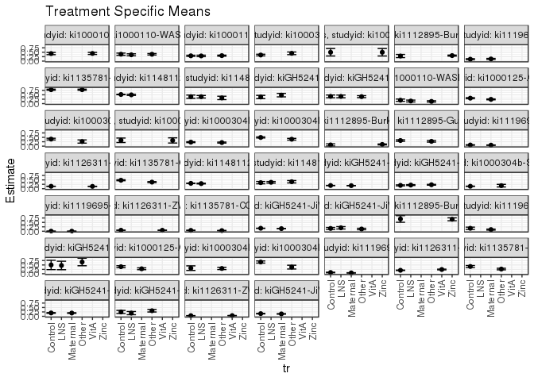

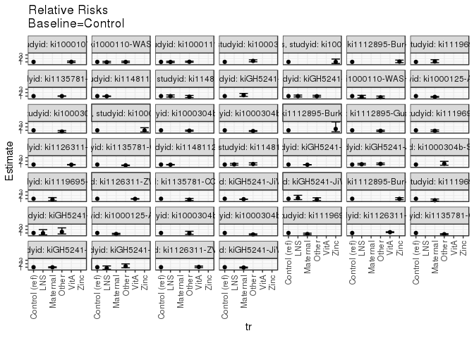

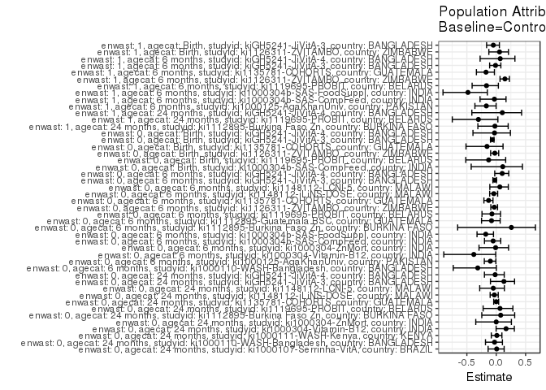

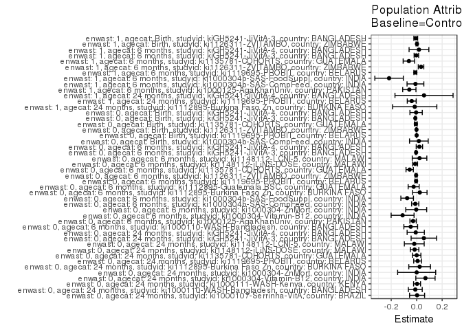

## Results Table

### Parameter: TSM

| enwast | agecat | studyid | country | intervention_level | baseline_level | estimate | ci_lower | ci_upper |
| --- | --- | --- | --- | --- | --- | --- | --- | --- |
| 0 | Birth | ki1000304b-SAS-CompFeed | INDIA | Control | NA | 0.1379310 | 0.1280315 | 0.1478305 |
| 0 | Birth | ki1000304b-SAS-CompFeed | INDIA | Other | NA | 0.1724138 | 0.0990749 | 0.2457527 |
| 0 | Birth | ki1119695-PROBIT | BELARUS | Control | NA | 0.0026835 | 0.0015283 | 0.0038388 |
| 0 | Birth | ki1119695-PROBIT | BELARUS | Maternal | NA | 0.0020983 | 0.0014177 | 0.0027789 |
| 0 | Birth | ki1126311-ZVITAMBO | ZIMBABWE | Control | NA | 0.0569832 | 0.0548145 | 0.0591520 |
| 0 | Birth | ki1126311-ZVITAMBO | ZIMBABWE | VitA | NA | 0.0551952 | 0.0514682 | 0.0589222 |
| 0 | Birth | ki1135781-COHORTS | GUATEMALA | Control | NA | 0.0492424 | 0.0370143 | 0.0614706 |
| 0 | Birth | ki1135781-COHORTS | GUATEMALA | Other | NA | 0.0366667 | 0.0253443 | 0.0479891 |
| 0 | Birth | kiGH5241-JiVitA-3 | BANGLADESH | Control | NA | 0.1688330 | 0.1639372 | 0.1737289 |
| 0 | Birth | kiGH5241-JiVitA-3 | BANGLADESH | Maternal | NA | 0.1480973 | 0.1437177 | 0.1524768 |
| 0 | Birth | kiGH5241-JiVitA-4 | BANGLADESH | Control | NA | 0.1590909 | 0.1033526 | 0.2148292 |
| 0 | Birth | kiGH5241-JiVitA-4 | BANGLADESH | LNS | NA | 0.1944444 | 0.1276620 | 0.2612269 |
| 0 | Birth | kiGH5241-JiVitA-4 | BANGLADESH | Other | NA | 0.1271478 | 0.0858390 | 0.1684565 |
| 0 | 6 months | ki1000110-WASH-Bangladesh | BANGLADESH | Control | NA | 0.1946309 | 0.1310099 | 0.2582519 |
| 0 | 6 months | ki1000110-WASH-Bangladesh | BANGLADESH | LNS | NA | 0.1468927 | 0.0947005 | 0.1990849 |
| 0 | 6 months | ki1000110-WASH-Bangladesh | BANGLADESH | Other | NA | 0.1262136 | 0.0891569 | 0.1632703 |
| 0 | 6 months | ki1000125-AgaKhanUniv | PAKISTAN | Control | NA | 0.3085106 | 0.2771340 | 0.3398873 |
| 0 | 6 months | ki1000125-AgaKhanUniv | PAKISTAN | Maternal | NA | 0.2413793 | 0.2167152 | 0.2660434 |
| 0 | 6 months | ki1000304-Vitamin-B12 | INDIA | Control | NA | 0.4000000 | 0.3507437 | 0.4492563 |
| 0 | 6 months | ki1000304-Vitamin-B12 | INDIA | Other | NA | 0.2622951 | 0.1731059 | 0.3514842 |
| 0 | 6 months | ki1000304-ZnMort | INDIA | Control | NA | 0.3333333 | 0.2069274 | 0.4597393 |
| 0 | 6 months | ki1000304-ZnMort | INDIA | Zinc | NA | 0.3250000 | 0.1790735 | 0.4709265 |
| 0 | 6 months | ki1000304b-SAS-CompFeed | INDIA | Control | NA | 0.2263374 | 0.2004475 | 0.2522274 |
| 0 | 6 months | ki1000304b-SAS-CompFeed | INDIA | Other | NA | 0.2040000 | 0.1772619 | 0.2307381 |
| 0 | 6 months | ki1000304b-SAS-FoodSuppl | INDIA | Control | NA | 0.4931507 | 0.4634093 | 0.5228921 |
| 0 | 6 months | ki1000304b-SAS-FoodSuppl | INDIA | Other | NA | 0.3923445 | 0.3431965 | 0.4414925 |
| 0 | 6 months | ki1112895-Burkina Faso Zn | BURKINA FASO | Control | NA | 0.0704225 | 0.0108544 | 0.1299907 |
| 0 | 6 months | ki1112895-Burkina Faso Zn | BURKINA FASO | Zinc | NA | 0.0985325 | 0.0717624 | 0.1253026 |
| 0 | 6 months | ki1112895-Guatemala BSC | GUATEMALA | Control | NA | 0.3203883 | 0.2758709 | 0.3649058 |
| 0 | 6 months | ki1112895-Guatemala BSC | GUATEMALA | Other | NA | 0.2735849 | 0.2304395 | 0.3167303 |

[output cut: 72 more lines]

### Parameter: E(Y)

| enwast | agecat | studyid | country | intervention_level | baseline_level | estimate | ci_lower | ci_upper |
| --- | --- | --- | --- | --- | --- | --- | --- | --- |
| 0 | Birth | ki1000304b-SAS-CompFeed | INDIA | NA | NA | 0.1551724 | 0.0811316 | 0.2292133 |
| 0 | Birth | ki1119695-PROBIT | BELARUS | NA | NA | 0.0023775 | 0.0010265 | 0.0037285 |
| 0 | Birth | ki1126311-ZVITAMBO | ZIMBABWE | NA | NA | 0.0556374 | 0.0513254 | 0.0599495 |
| 0 | Birth | ki1135781-COHORTS | GUATEMALA | NA | NA | 0.0425532 | 0.0258801 | 0.0592263 |
| 0 | Birth | kiGH5241-JiVitA-3 | BANGLADESH | NA | NA | 0.1582060 | 0.1515770 | 0.1648351 |
| 0 | Birth | kiGH5241-JiVitA-4 | BANGLADESH | NA | NA | 0.1545595 | 0.1240892 | 0.1850299 |
| 0 | 6 months | ki1000110-WASH-Bangladesh | BANGLADESH | NA | NA | 0.1480315 | 0.1203880 | 0.1756749 |
| 0 | 6 months | ki1000125-AgaKhanUniv | PAKISTAN | NA | NA | 0.2804124 | 0.2403934 | 0.3204313 |
| 0 | 6 months | ki1000304-Vitamin-B12 | INDIA | NA | NA | 0.2894737 | 0.1868348 | 0.3921126 |
| 0 | 6 months | ki1000304-ZnMort | INDIA | NA | NA | 0.3297872 | 0.2342374 | 0.4253371 |
| 0 | 6 months | ki1000304b-SAS-CompFeed | INDIA | NA | NA | 0.2150101 | 0.1761196 | 0.2539007 |
| 0 | 6 months | ki1000304b-SAS-FoodSuppl | INDIA | NA | NA | 0.4184397 | 0.3607619 | 0.4761175 |
| 0 | 6 months | ki1112895-Burkina Faso Zn | BURKINA FASO | NA | NA | 0.0948905 | 0.0703312 | 0.1194498 |
| 0 | 6 months | ki1112895-Guatemala BSC | GUATEMALA | NA | NA | 0.2966507 | 0.2345746 | 0.3587268 |
| 0 | 6 months | ki1119695-PROBIT | BELARUS | NA | NA | 0.0620147 | 0.0454111 | 0.0786183 |
| 0 | 6 months | ki1126311-ZVITAMBO | ZIMBABWE | NA | NA | 0.1326247 | 0.1241231 | 0.1411263 |
| 0 | 6 months | ki1135781-COHORTS | GUATEMALA | NA | NA | 0.4234079 | 0.3831966 | 0.4636192 |
| 0 | 6 months | ki1148112-iLiNS-DOSE | MALAWI | NA | NA | 0.2919868 | 0.2711037 | 0.3128699 |
| 0 | 6 months | ki1148112-LCNI-5 | MALAWI | NA | NA | 0.3657635 | 0.3326151 | 0.3989120 |
| 0 | 6 months | kiGH5241-JiVitA-3 | BANGLADESH | NA | NA | 0.1779511 | 0.1701238 | 0.1857784 |
| 0 | 6 months | kiGH5241-JiVitA-4 | BANGLADESH | NA | NA | 0.2101488 | 0.1951229 | 0.2251747 |
| 0 | 24 months | ki1000107-Serrinha-VitA | BRAZIL | NA | NA | 0.4296875 | 0.3435923 | 0.5157827 |
| 0 | 24 months | ki1000110-WASH-Bangladesh | BANGLADESH | NA | NA | 0.3789370 | 0.3490924 | 0.4087817 |
| 0 | 24 months | ki1000111-WASH-Kenya | KENYA | NA | NA | 0.3023148 | 0.2829425 | 0.3216871 |
| 0 | 24 months | ki1000304-Vitamin-B12 | INDIA | NA | NA | 0.4117647 | 0.3229659 | 0.5005635 |
| 0 | 24 months | ki1000304-ZnMort | INDIA | NA | NA | 0.5000000 | 0.3505541 | 0.6494459 |
| 0 | 24 months | ki1112895-Burkina Faso Zn | BURKINA FASO | NA | NA | 0.3091266 | 0.2807381 | 0.3375150 |
| 0 | 24 months | ki1119695-PROBIT | BELARUS | NA | NA | 0.1143317 | 0.0717136 | 0.1569498 |
| 0 | 24 months | ki1135781-COHORTS | GUATEMALA | NA | NA | 0.7876712 | 0.7406841 | 0.8346583 |
| 0 | 24 months | ki1148112-iLiNS-DOSE | MALAWI | NA | NA | 0.5006897 | 0.4642689 | 0.5371104 |
| 0 | 24 months | ki1148112-LCNI-5 | MALAWI | NA | NA | 0.3736559 | 0.3244289 | 0.4228829 |
| 0 | 24 months | kiGH5241-JiVitA-3 | BANGLADESH | NA | NA | 0.4313725 | 0.2945455 | 0.5681996 |
| 0 | 24 months | kiGH5241-JiVitA-4 | BANGLADESH | NA | NA | 0.4025478 | 0.3631810 | 0.4419145 |
| 1 | Birth | ki1126311-ZVITAMBO | ZIMBABWE | NA | NA | 0.0402504 | 0.0321020 | 0.0483989 |
| 1 | Birth | kiGH5241-JiVitA-3 | BANGLADESH | NA | NA | 0.1446174 | 0.1236010 | 0.1656338 |
| 1 | 6 months | ki1000125-AgaKhanUniv | PAKISTAN | NA | NA | 0.3422819 | 0.2658404 | 0.4187234 |
| 1 | 6 months | ki1000304b-SAS-CompFeed | INDIA | NA | NA | 0.3103448 | 0.1653334 | 0.4553562 |
| 1 | 6 months | ki1000304b-SAS-FoodSuppl | INDIA | NA | NA | 0.4500000 | 0.3230567 | 0.5769433 |
| 1 | 6 months | ki1119695-PROBIT | BELARUS | NA | NA | 0.0625483 | 0.0409961 | 0.0841004 |
| 1 | 6 months | ki1126311-ZVITAMBO | ZIMBABWE | NA | NA | 0.2315141 | 0.2069751 | 0.2560531 |
| 1 | 6 months | ki1135781-COHORTS | GUATEMALA | NA | NA | 0.3511905 | 0.2787936 | 0.4235874 |
| 1 | 6 months | kiGH5241-JiVitA-3 | BANGLADESH | NA | NA | 0.1882986 | 0.1630446 | 0.2135526 |
| 1 | 6 months | kiGH5241-JiVitA-4 | BANGLADESH | NA | NA | 0.2654155 | 0.2173146 | 0.3135165 |
| 1 | 24 months | ki1112895-Burkina Faso Zn | BURKINA FASO | NA | NA | 0.6802721 | 0.6046231 | 0.7559211 |
| 1 | 24 months | ki1119695-PROBIT | BELARUS | NA | NA | 0.1278539 | 0.0556743 | 0.2000335 |
| 1 | 24 months | kiGH5241-JiVitA-4 | BANGLADESH | NA | NA | 0.5576923 | 0.4187065 | 0.6966781 |

### Parameter: RR

| enwast | agecat | studyid | country | intervention_level | baseline_level | estimate | ci_lower | ci_upper |
| --- | --- | --- | --- | --- | --- | --- | --- | --- |
| 0 | Birth | ki1000304b-SAS-CompFeed | INDIA | Control | Control | 1.0000000 | 1.0000000 | 1.0000000 |
| 0 | Birth | ki1000304b-SAS-CompFeed | INDIA | Other | Control | 1.2500000 | 0.8120365 | 1.9241745 |
| 0 | Birth | ki1119695-PROBIT | BELARUS | Control | Control | 1.0000000 | 1.0000000 | 1.0000000 |
| 0 | Birth | ki1119695-PROBIT | BELARUS | Maternal | Control | 0.7819049 | 0.4562380 | 1.3400359 |
| 0 | Birth | ki1126311-ZVITAMBO | ZIMBABWE | Control | Control | 1.0000000 | 1.0000000 | 1.0000000 |
| 0 | Birth | ki1126311-ZVITAMBO | ZIMBABWE | VitA | Control | 0.9686217 | 0.8963790 | 1.0466867 |
| 0 | Birth | ki1135781-COHORTS | GUATEMALA | Control | Control | 1.0000000 | 1.0000000 | 1.0000000 |
| 0 | Birth | ki1135781-COHORTS | GUATEMALA | Other | Control | 0.7446154 | 0.5010029 | 1.1066844 |
| 0 | Birth | kiGH5241-JiVitA-3 | BANGLADESH | Control | Control | 1.0000000 | 1.0000000 | 1.0000000 |
| 0 | Birth | kiGH5241-JiVitA-3 | BANGLADESH | Maternal | Control | 0.8771818 | 0.8415914 | 0.9142771 |
| 0 | Birth | kiGH5241-JiVitA-4 | BANGLADESH | Control | Control | 1.0000000 | 1.0000000 | 1.0000000 |
| 0 | Birth | kiGH5241-JiVitA-4 | BANGLADESH | LNS | Control | 1.2222222 | 0.7482884 | 1.9963255 |
| 0 | Birth | kiGH5241-JiVitA-4 | BANGLADESH | Other | Control | 0.7992145 | 0.4956085 | 1.2888073 |
| 0 | 6 months | ki1000110-WASH-Bangladesh | BANGLADESH | Control | Control | 1.0000000 | 1.0000000 | 1.0000000 |
| 0 | 6 months | ki1000110-WASH-Bangladesh | BANGLADESH | LNS | Control | 0.7547243 | 0.4657056 | 1.2231093 |
| 0 | 6 months | ki1000110-WASH-Bangladesh | BANGLADESH | Other | Control | 0.6484767 | 0.4179022 | 1.0062690 |
| 0 | 6 months | ki1000125-AgaKhanUniv | PAKISTAN | Control | Control | 1.0000000 | 1.0000000 | 1.0000000 |
| 0 | 6 months | ki1000125-AgaKhanUniv | PAKISTAN | Maternal | Control | 0.7824019 | 0.6773586 | 0.9037351 |
| 0 | 6 months | ki1000304-Vitamin-B12 | INDIA | Control | Control | 1.0000000 | 1.0000000 | 1.0000000 |
| 0 | 6 months | ki1000304-Vitamin-B12 | INDIA | Other | Control | 0.6557377 | 0.4567411 | 0.9414348 |
| 0 | 6 months | ki1000304-ZnMort | INDIA | Control | Control | 1.0000000 | 1.0000000 | 1.0000000 |
| 0 | 6 months | ki1000304-ZnMort | INDIA | Zinc | Control | 0.9750000 | 0.5417044 | 1.7548776 |
| 0 | 6 months | ki1000304b-SAS-CompFeed | INDIA | Control | Control | 1.0000000 | 1.0000000 | 1.0000000 |
| 0 | 6 months | ki1000304b-SAS-CompFeed | INDIA | Other | Control | 0.9013091 | 0.7575162 | 1.0723969 |
| 0 | 6 months | ki1000304b-SAS-FoodSuppl | INDIA | Control | Control | 1.0000000 | 1.0000000 | 1.0000000 |
| 0 | 6 months | ki1000304b-SAS-FoodSuppl | INDIA | Other | Control | 0.7955875 | 0.6923223 | 0.9142554 |
| 0 | 6 months | ki1112895-Burkina Faso Zn | BURKINA FASO | Control | Control | 1.0000000 | 1.0000000 | 1.0000000 |
| 0 | 6 months | ki1112895-Burkina Faso Zn | BURKINA FASO | Zinc | Control | 1.3991614 | 0.5754768 | 3.4017925 |
| 0 | 6 months | ki1112895-Guatemala BSC | GUATEMALA | Control | Control | 1.0000000 | 1.0000000 | 1.0000000 |
| 0 | 6 months | ki1112895-Guatemala BSC | GUATEMALA | Other | Control | 0.8539165 | 0.6920441 | 1.0536517 |

[output cut: 72 more lines]

### Parameter: PAR

| enwast | agecat | studyid | country | intervention_level | baseline_level | estimate | ci_lower | ci_upper |
| --- | --- | --- | --- | --- | --- | --- | --- | --- |
| 0 | Birth | ki1000304b-SAS-CompFeed | INDIA | Control | NA | 0.0172414 | -0.0561384 | 0.0906212 |
| 0 | Birth | ki1119695-PROBIT | BELARUS | Control | NA | -0.0003061 | -0.0009974 | 0.0003853 |
| 0 | Birth | ki1126311-ZVITAMBO | ZIMBABWE | Control | NA | -0.0013458 | -0.0050728 | 0.0023812 |
| 0 | Birth | ki1135781-COHORTS | GUATEMALA | Control | NA | -0.0066892 | -0.0180235 | 0.0046450 |
| 0 | Birth | kiGH5241-JiVitA-3 | BANGLADESH | Control | NA | -0.0106270 | -0.0151014 | -0.0061527 |
| 0 | Birth | kiGH5241-JiVitA-4 | BANGLADESH | Control | NA | -0.0045314 | -0.0529708 | 0.0439080 |
| 0 | 6 months | ki1000110-WASH-Bangladesh | BANGLADESH | Control | NA | -0.0465994 | -0.1005649 | 0.0073661 |
| 0 | 6 months | ki1000125-AgaKhanUniv | PAKISTAN | Control | NA | -0.0280983 | -0.0529382 | -0.0032583 |
| 0 | 6 months | ki1000304-Vitamin-B12 | INDIA | Control | NA | -0.1105263 | -0.2005739 | -0.0204788 |
| 0 | 6 months | ki1000304-ZnMort | INDIA | Control | NA | -0.0035461 | -0.0857045 | 0.0786123 |
| 0 | 6 months | ki1000304b-SAS-CompFeed | INDIA | Control | NA | -0.0113273 | -0.0394443 | 0.0167896 |
| 0 | 6 months | ki1000304b-SAS-FoodSuppl | INDIA | Control | NA | -0.0747110 | -0.1241294 | -0.0252925 |
| 0 | 6 months | ki1112895-Burkina Faso Zn | BURKINA FASO | Control | NA | 0.0244680 | -0.0323832 | 0.0813192 |
| 0 | 6 months | ki1112895-Guatemala BSC | GUATEMALA | Control | NA | -0.0237376 | -0.0670001 | 0.0195248 |
| 0 | 6 months | ki1119695-PROBIT | BELARUS | Control | NA | -0.0045371 | -0.0135264 | 0.0044522 |
| 0 | 6 months | ki1126311-ZVITAMBO | ZIMBABWE | Control | NA | -0.0044345 | -0.0117838 | 0.0029148 |
| 0 | 6 months | ki1135781-COHORTS | GUATEMALA | Control | NA | -0.0550093 | -0.0837521 | -0.0262666 |
| 0 | 6 months | ki1148112-iLiNS-DOSE | MALAWI | Control | NA | -0.0120672 | -0.0311351 | 0.0070007 |
| 0 | 6 months | ki1148112-LCNI-5 | MALAWI | Control | NA | 0.0224800 | -0.0347651 | 0.0797251 |
| 0 | 6 months | kiGH5241-JiVitA-3 | BANGLADESH | Control | NA | -0.0045546 | -0.0098599 | 0.0007506 |
| 0 | 6 months | kiGH5241-JiVitA-4 | BANGLADESH | Control | NA | 0.0213733 | -0.0036200 | 0.0463665 |
| 0 | 24 months | ki1000107-Serrinha-VitA | BRAZIL | Control | NA | 0.0032169 | -0.0557915 | 0.0622253 |
| 0 | 24 months | ki1000110-WASH-Bangladesh | BANGLADESH | Control | NA | -0.0108935 | -0.0653529 | 0.0435659 |
| 0 | 24 months | ki1000111-WASH-Kenya | KENYA | Control | NA | 0.0031458 | -0.0241533 | 0.0304449 |
| 0 | 24 months | ki1000304-Vitamin-B12 | INDIA | Control | NA | 0.0689076 | -0.0067756 | 0.1445907 |
| 0 | 24 months | ki1000304-ZnMort | INDIA | Control | NA | 0.0000000 | -0.1494459 | 0.1494459 |
| 0 | 24 months | ki1112895-Burkina Faso Zn | BURKINA FASO | Control | NA | 0.0234123 | -0.0618710 | 0.1086957 |
| 0 | 24 months | ki1119695-PROBIT | BELARUS | Control | NA | 0.0073207 | -0.0232120 | 0.0378534 |
| 0 | 24 months | ki1135781-COHORTS | GUATEMALA | Control | NA | 0.0000000 | -0.0332249 | 0.0332249 |
| 0 | 24 months | ki1148112-iLiNS-DOSE | MALAWI | Control | NA | -0.0162595 | -0.0495885 | 0.0170695 |
| 0 | 24 months | ki1148112-LCNI-5 | MALAWI | Control | NA | -0.0188675 | -0.0967718 | 0.0590369 |
| 0 | 24 months | kiGH5241-JiVitA-3 | BANGLADESH | Control | NA | 0.0563725 | -0.0436215 | 0.1563666 |
| 0 | 24 months | kiGH5241-JiVitA-4 | BANGLADESH | Control | NA | -0.0074522 | -0.0750089 | 0.0601045 |
| 1 | Birth | ki1126311-ZVITAMBO | ZIMBABWE | Control | NA | 0.0022539 | -0.0048262 | 0.0093340 |
| 1 | Birth | kiGH5241-JiVitA-3 | BANGLADESH | Control | NA | -0.0071683 | -0.0221171 | 0.0077804 |
| 1 | 6 months | ki1000125-AgaKhanUniv | PAKISTAN | Control | NA | -0.0577181 | -0.1097537 | -0.0056826 |
| 1 | 6 months | ki1000304b-SAS-CompFeed | INDIA | Control | NA | -0.0096552 | -0.0756341 | 0.0563238 |
| 1 | 6 months | ki1000304b-SAS-FoodSuppl | INDIA | Control | NA | -0.2166667 | -0.3284584 | -0.1048749 |
| 1 | 6 months | ki1119695-PROBIT | BELARUS | Control | NA | -0.0103759 | -0.0219019 | 0.0011501 |
| 1 | 6 months | ki1126311-ZVITAMBO | ZIMBABWE | Control | NA | 0.0342823 | 0.0126991 | 0.0558654 |
| 1 | 6 months | ki1135781-COHORTS | GUATEMALA | Control | NA | -0.0611807 | -0.1061579 | -0.0162034 |
| 1 | 6 months | kiGH5241-JiVitA-3 | BANGLADESH | Control | NA | -0.0023019 | -0.0200290 | 0.0154251 |
| 1 | 6 months | kiGH5241-JiVitA-4 | BANGLADESH | Control | NA | 0.0179929 | -0.0596129 | 0.0955986 |
| 1 | 24 months | ki1112895-Burkina Faso Zn | BURKINA FASO | Control | NA | -0.0153801 | -0.1891189 | 0.1583588 |
| 1 | 24 months | ki1119695-PROBIT | BELARUS | Control | NA | -0.0388128 | -0.0737439 | -0.0038817 |
| 1 | 24 months | kiGH5241-JiVitA-4 | BANGLADESH | Control | NA | 0.0576923 | -0.1703540 | 0.2857386 |

### Parameter: PAF

| enwast | agecat | studyid | country | intervention_level | baseline_level | estimate | ci_lower | ci_upper |
| --- | --- | --- | --- | --- | --- | --- | --- | --- |
| 0 | Birth | ki1000304b-SAS-CompFeed | INDIA | Control | NA | 0.1111111 | -0.4264364 | 0.4460858 |
| 0 | Birth | ki1119695-PROBIT | BELARUS | Control | NA | -0.1287359 | -0.5182518 | 0.1608475 |
| 0 | Birth | ki1126311-ZVITAMBO | ZIMBABWE | Control | NA | -0.0241888 | -0.0951537 | 0.0421776 |
| 0 | Birth | ki1135781-COHORTS | GUATEMALA | Control | NA | -0.1571970 | -0.5146757 | 0.1159132 |
| 0 | Birth | kiGH5241-JiVitA-3 | BANGLADESH | Control | NA | -0.0671721 | -0.0978560 | -0.0373458 |
| 0 | Birth | kiGH5241-JiVitA-4 | BANGLADESH | Control | NA | -0.0293182 | -0.3961861 | 0.2411500 |
| 0 | 6 months | ki1000110-WASH-Bangladesh | BANGLADESH | Control | NA | -0.3147937 | -0.7314964 | 0.0016252 |
| 0 | 6 months | ki1000125-AgaKhanUniv | PAKISTAN | Control | NA | -0.1002034 | -0.2028129 | -0.0063473 |
| 0 | 6 months | ki1000304-Vitamin-B12 | INDIA | Control | NA | -0.3818182 | -0.8927045 | -0.0088324 |
| 0 | 6 months | ki1000304-ZnMort | INDIA | Control | NA | -0.0107527 | -0.2932654 | 0.2100453 |
| 0 | 6 months | ki1000304b-SAS-CompFeed | INDIA | Control | NA | -0.0526827 | -0.2001712 | 0.0766811 |
| 0 | 6 months | ki1000304b-SAS-FoodSuppl | INDIA | Control | NA | -0.1785466 | -0.3269372 | -0.0467503 |
| 0 | 6 months | ki1112895-Burkina Faso Zn | BURKINA FASO | Control | NA | 0.2578548 | -0.6567145 | 0.6675471 |
| 0 | 6 months | ki1112895-Guatemala BSC | GUATEMALA | Control | NA | -0.0800188 | -0.2501180 | 0.0669356 |
| 0 | 6 months | ki1119695-PROBIT | BELARUS | Control | NA | -0.0731618 | -0.2423705 | 0.0730009 |
| 0 | 6 months | ki1126311-ZVITAMBO | ZIMBABWE | Control | NA | -0.0334366 | -0.0923309 | 0.0222823 |
| 0 | 6 months | ki1135781-COHORTS | GUATEMALA | Control | NA | -0.1299205 | -0.2098057 | -0.0553101 |
| 0 | 6 months | ki1148112-iLiNS-DOSE | MALAWI | Control | NA | -0.0413280 | -0.1116118 | 0.0245120 |
| 0 | 6 months | ki1148112-LCNI-5 | MALAWI | Control | NA | 0.0614604 | -0.1088639 | 0.2056224 |
| 0 | 6 months | kiGH5241-JiVitA-3 | BANGLADESH | Control | NA | -0.0255949 | -0.0566426 | 0.0045404 |
| 0 | 6 months | kiGH5241-JiVitA-4 | BANGLADESH | Control | NA | 0.1017054 | -0.0255370 | 0.2131603 |
| 0 | 24 months | ki1000107-Serrinha-VitA | BRAZIL | Control | NA | 0.0074866 | -0.1386214 | 0.1348461 |
| 0 | 24 months | ki1000110-WASH-Bangladesh | BANGLADESH | Control | NA | -0.0287475 | -0.1829918 | 0.1053856 |
| 0 | 24 months | ki1000111-WASH-Kenya | KENYA | Control | NA | 0.0104058 | -0.0841422 | 0.0967084 |
| 0 | 24 months | ki1000304-Vitamin-B12 | INDIA | Control | NA | 0.1673469 | -0.0020587 | 0.3081133 |
| 0 | 24 months | ki1000304-ZnMort | INDIA | Control | NA | 0.0000000 | -0.3483636 | 0.2583603 |
| 0 | 24 months | ki1112895-Burkina Faso Zn | BURKINA FASO | Control | NA | 0.0757370 | -0.2457238 | 0.3142443 |
| 0 | 24 months | ki1119695-PROBIT | BELARUS | Control | NA | 0.0640299 | -0.2232396 | 0.2838362 |
| 0 | 24 months | ki1135781-COHORTS | GUATEMALA | Control | NA | 0.0000000 | -0.0430834 | 0.0413039 |
| 0 | 24 months | ki1148112-iLiNS-DOSE | MALAWI | Control | NA | -0.0324742 | -0.1035482 | 0.0340223 |
| 0 | 24 months | ki1148112-LCNI-5 | MALAWI | Control | NA | -0.0504942 | -0.2811483 | 0.1386337 |
| 0 | 24 months | kiGH5241-JiVitA-3 | BANGLADESH | Control | NA | 0.1306818 | -0.0985442 | 0.3120768 |
| 0 | 24 months | kiGH5241-JiVitA-4 | BANGLADESH | Control | NA | -0.0185127 | -0.2009598 | 0.1362175 |
| 1 | Birth | ki1126311-ZVITAMBO | ZIMBABWE | Control | NA | 0.0559969 | -0.1256680 | 0.2083441 |
| 1 | Birth | kiGH5241-JiVitA-3 | BANGLADESH | Control | NA | -0.0495676 | -0.1640002 | 0.0536152 |
| 1 | 6 months | ki1000125-AgaKhanUniv | PAKISTAN | Control | NA | -0.1686275 | -0.3629852 | -0.0019846 |
| 1 | 6 months | ki1000304b-SAS-CompFeed | INDIA | Control | NA | -0.0311111 | -0.2757593 | 0.1666217 |
| 1 | 6 months | ki1000304b-SAS-FoodSuppl | INDIA | Control | NA | -0.4814815 | -0.9064399 | -0.1512492 |
| 1 | 6 months | ki1119695-PROBIT | BELARUS | Control | NA | -0.1658867 | -0.4106518 | 0.0364087 |
| 1 | 6 months | ki1126311-ZVITAMBO | ZIMBABWE | Control | NA | 0.1480785 | 0.0644525 | 0.2242293 |
| 1 | 6 months | ki1135781-COHORTS | GUATEMALA | Control | NA | -0.1742093 | -0.3376162 | -0.0307647 |
| 1 | 6 months | kiGH5241-JiVitA-3 | BANGLADESH | Control | NA | -0.0122249 | -0.1121569 | 0.0787277 |
| 1 | 6 months | kiGH5241-JiVitA-4 | BANGLADESH | Control | NA | 0.0677913 | -0.2746253 | 0.3182208 |
| 1 | 24 months | ki1112895-Burkina Faso Zn | BURKINA FASO | Control | NA | -0.0226087 | -0.3127800 | 0.2034244 |
| 1 | 24 months | ki1119695-PROBIT | BELARUS | Control | NA | -0.3035714 | -0.7484935 | 0.0281357 |
| 1 | 24 months | kiGH5241-JiVitA-4 | BANGLADESH | Control | NA | 0.1034483 | -0.4152237 | 0.4320297 |